# Time Series Imputations

Adham Suliman

November 27, 2018

Since there are multiple purchases in the same month, the average price of a seat is taken.

```r
df <- as.data.frame(read.csv('cmeS.csv'))
(df2 <- df %>%
  group_by(Year, Month, division) %>%
  summarize(Avg_Price = mean(price)))
```

```
## # A tibble: 134 x 4
## # Groups:   Year, Month [?]
##     Year Month division Avg_Price
##    <int> <int> <fct>        <dbl>
##  1  2001     1 CME         188000
##  2  2001     2 CME         250000
##  3  2001     3 CME         250000
##  4  2001     5 CME         325000
##  5  2001     6 CME         375000
##  6  2001    11 CME         305000
##  7  2001    12 CME         360000
##  8  2002     1 CME         395000
##  9  2002     2 CME         400000
## 10  2002     4 CME         400000
## # ... with 124 more rows
```

Convert date data to date data type.

```r
df2$Date <- as.Date(strftime(strptime((paste(1, df2$Month, df2$Year)),"%d %m %Y"),"%Y-%m-%d"),"%Y-%m-%d")
```

Create another data set which will have all dates

```r
Date<- c(seq(as.Date("2001/1/1"), by = "month", length.out = 156))
dfx <- data.frame(Date)
```

Merge original dataset with continious date data set.

```r
df3 <- merge(x = dfx, y = df2, by = "Date", all.x = TRUE)
df3 <- df3[,c('Date','division','Avg_Price')]
df3$division <- "CME"
air.mon<- ts(df3$Avg_Price,12)
```

Some exploratory analysis of where there is data, and where there is not.

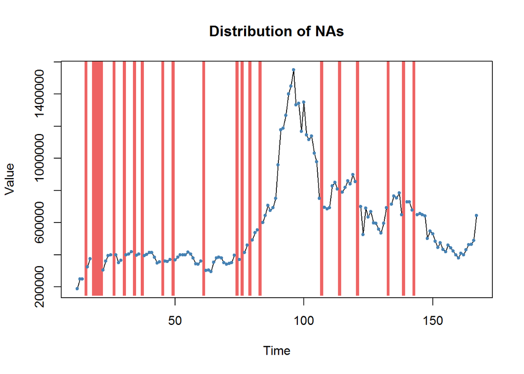

```r
plotNA.distribution(air.mon) #shows the missing
```

```r
statsNA(air.mon)
```

```
## [1] "Length of time series:"
## [1] 156
## [1] "-------------------------"
## [1] "Number of Missing Values:"
## [1] 22
## [1] "-------------------------"
## [1] "Percentage of Missing Values:"
## [1] "14.1%"
## [1] "-------------------------"
## [1] "Stats for Bins"
## [1] "  Bin 1 (39 values from 1 to 39) :      11 NAs (28.2%)"
## [1] "  Bin 2 (39 values from 40 to 78) :      5 NAs (12.8%)"
## [1] "  Bin 3 (39 values from 79 to 117) :      3 NAs (7.69%)"
## [1] "  Bin 4 (39 values from 118 to 156) :      3 NAs (7.69%)"
## [1] "-------------------------"
## [1] "Longest NA gap (series of consecutive NAs)"
## [1] "4 in a row"
## [1] "-------------------------"
## [1] "Most frequent gap size (series of consecutive NA series)"
## [1] "1 NA in a row (occuring 18 times)"
## [1] "-------------------------"
## [1] "Gap size accounting for most NAs"
## [1] "1 NA in a row (occuring 18 times, making up for overall 18 NAs)"
## [1] "-------------------------"
## [1] "Overview NA series"
## [1] "  1 NA in a row: 18 times"
## [1] "  4 NA in a row: 1 times"
```

The data is filled with three different methods: Linear, Spline, and Weighted Moving Average. The linear model simply skips over any missing data and connects the previous point to the later point utilizing a straight line. A spline is created utilizing piecewise polynomials to create a non-linear line. The moving average model looks at a period, in this case 12 moths, and uses a weighted average of those months to create missing data. It is up to interpretation to decide which method makes the most sense for a particular user, but I find the MA to make the most sense in this scenario. The linear line is too unrealistic, and spline seems to dip too hard in the early 200s and in 2008.

```r
a <- na.interpolation(air.mon, "linear")
b <- na.interpolation(air.mon, "spline")
c <- na.seadec(air.mon, "ma")
```

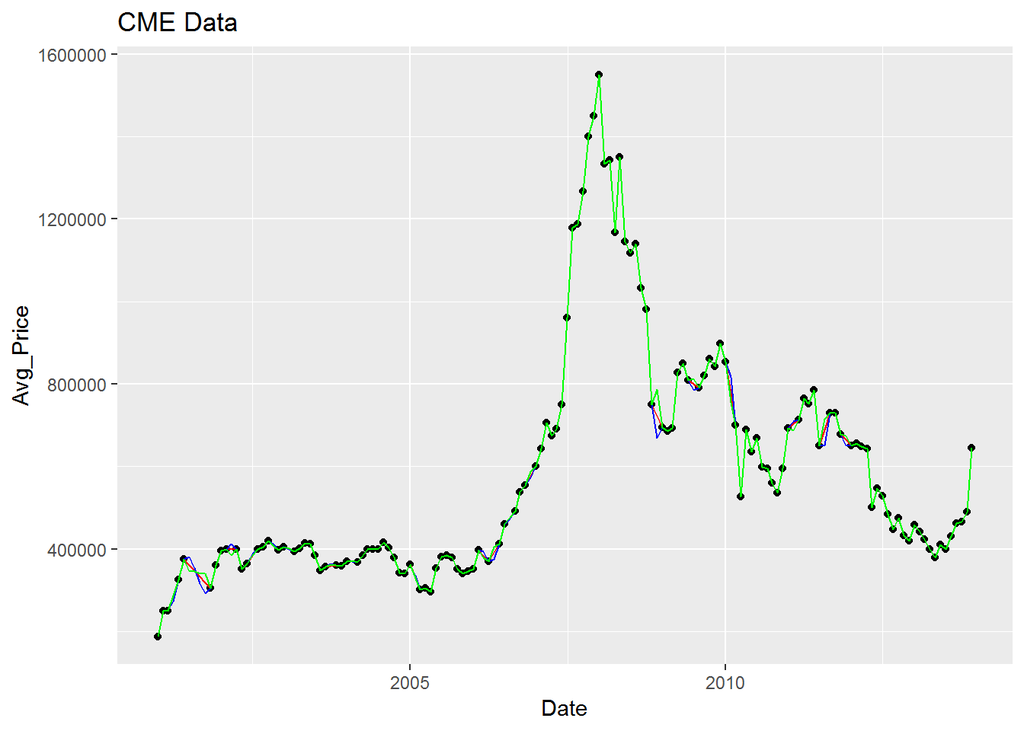

```r
ggplot(df3, aes(x=Date,y=Avg_Price)) + geom_point() + geom_line() +
  geom_line(aes(y=a),color='red',position=position_jitter(w=0.02, h=0))+
  geom_line(aes(y=b),color='blue',position=position_jitter(w=0, h=.05))+
  geom_line(aes(y=c),color='green')+
  ggtitle("CME Data")
```

The same methods used above will be used on the IOM data set

```r
iom <- read_csv('iomS.csv')
(df_iom <- iom %>%
  group_by(Year, Month, division) %>%
  summarize(Avg_Price = mean(price)))
```

```
## # A tibble: 147 x 4
## # Groups:   Year, Month [?]
##    Year    Month   division Avg_Price
##    <chr>   <chr>   <chr>        <dbl>
##  1 #VALUE! #VALUE! IOM         356000
##  2 2001    1       IOM         130000
##  3 2001    10      IOM         231250
##  4 2001    11      IOM         243000
##  5 2001    12      IOM         246000
##  6 2001    2       IOM         170000
##  7 2001    3       IOM         242500
##  8 2001    4       IOM         291500
##  9 2001    6       IOM         260000
## 10 2001    7       IOM         260000
## # ... with 137 more rows
```

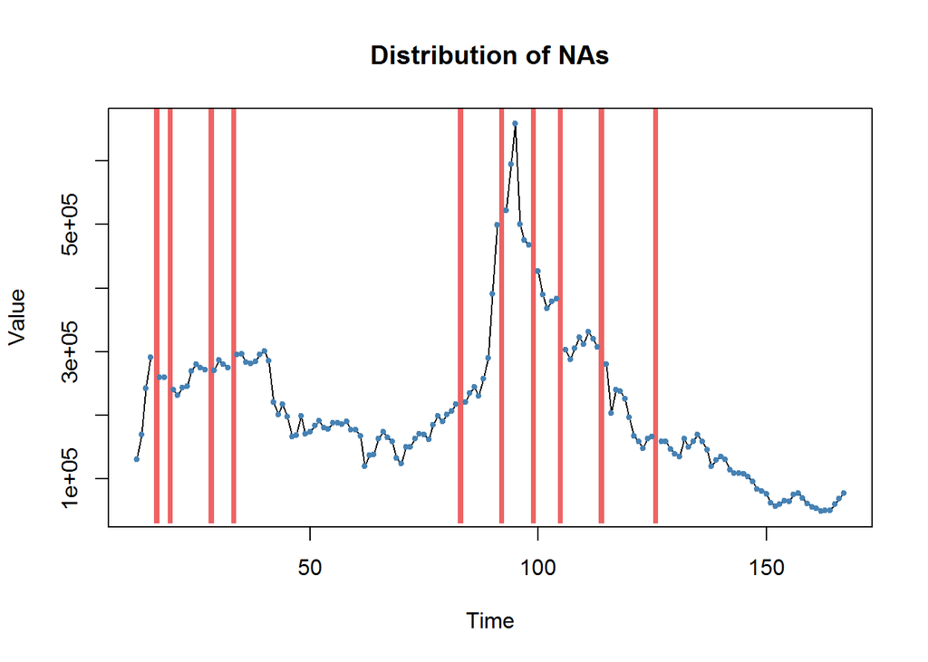

```r
df_iom$Date <- as.Date(strftime(strptime((paste(1, df_iom$Month, df_iom$Year)),"%d %m %Y"),"%Y-%m-%d"),"%Y-%m-%d")
Date<- c(seq(as.Date("2001/1/1"), by = "month", length.out = 156))
dfx <- data.frame(Date)
df3 <- merge(x = dfx, y = df_iom, by = "Date", all.x = TRUE)
df3 <- df3[,c('Date','division','Avg_Price')]
df3$division <- "IOM"
air.mon<- ts(df3$Avg_Price,12)
plotNA.distribution(air.mon) #shows the missing
```

```r
statsNA(air.mon)
```

```
## [1] "Length of time series:"
## [1] 156
## [1] "-------------------------"
## [1] "Number of Missing Values:"
## [1] 10
## [1] "-------------------------"
## [1] "Percentage of Missing Values:"
## [1] "6.41%"
## [1] "-------------------------"
## [1] "Stats for Bins"
## [1] "  Bin 1 (39 values from 1 to 39) :      4 NAs (10.3%)"
## [1] "  Bin 2 (39 values from 40 to 78) :      1 NAs (2.56%)"
## [1] "  Bin 3 (39 values from 79 to 117) :      5 NAs (12.8%)"
## [1] "  Bin 4 (39 values from 118 to 156) :      0 NAs (0%)"
## [1] "-------------------------"
## [1] "Longest NA gap (series of consecutive NAs)"
## [1] "1 in a row"
## [1] "-------------------------"
## [1] "Most frequent gap size (series of consecutive NA series)"
## [1] "1 NA in a row (occuring 10 times)"
## [1] "-------------------------"
## [1] "Gap size accounting for most NAs"
## [1] "1 NA in a row (occuring 10 times, making up for overall 10 NAs)"
## [1] "-------------------------"
## [1] "Overview NA series"
## [1] "  1 NA in a row: 10 times"
```

```r
a <- na.interpolation(air.mon, "linear")
b <- na.interpolation(air.mon, "spline")
c <- na.seadec(air.mon, "ma")
```

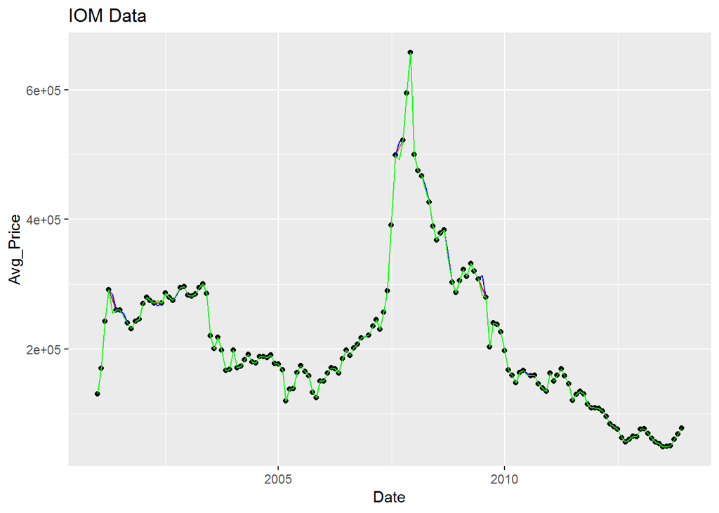

```r
ggplot(df3, aes(x=Date,y=Avg_Price)) + geom_point() + geom_line() +
  geom_line(aes(y=a),color='red',position=position_jitter(w=0.02, h=0))+
  geom_line(aes(y=b),color='blue',position=position_jitter(w=0, h=.05))+
  geom_line(aes(y=c),color='green') +
  ggtitle("IOM Data")
```

```r
imm <- read_csv('immS.csv')
(df_imm<- imm %>%
  group_by(Year, Month, division) %>%
  summarize(Avg_Price = mean(price)))
```

```
## # A tibble: 146 x 4
## # Groups:   Year, Month [?]
##     Year Month division Avg_Price
##    <int> <int> <chr>        <dbl>
##  1  2001     1 IMM        183125
##  2  2001     2 IMM        225000
##  3  2001     3 IMM        292500
##  4  2001     5 IMM        305000
##  5  2001     6 IMM        355333.
##  6  2001     7 IMM        355000
##  7  2001     9 IMM        338333.
##  8  2001    10 IMM        316667.
##  9  2001    11 IMM        318333.
## 10  2001    12 IMM        344833.
## # ... with 136 more rows
```

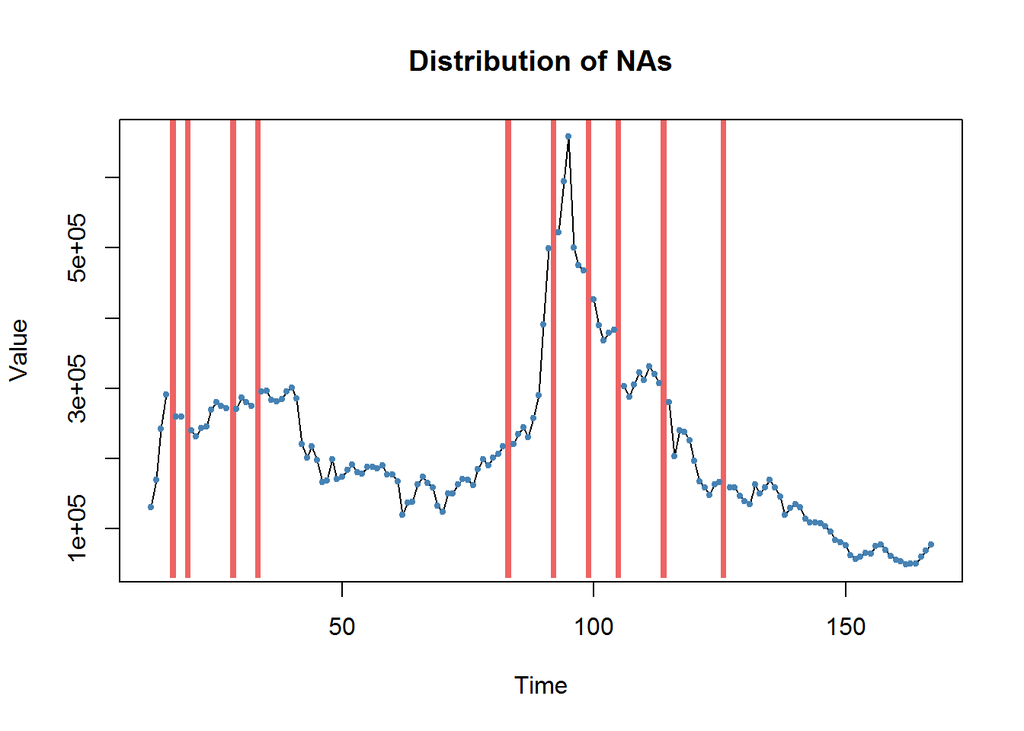

```r
df_iom$Date <- as.Date(strftime(strptime((paste(1, df_iom$Month, df_iom$Year)),"%d %m %Y"),"%Y-%m-%d"),"%Y-%m-%d")
Date<- c(seq(as.Date("2001/1/1"), by = "month", length.out = 156))
dfx <- data.frame(Date)
df3 <- merge(x = dfx, y = df_iom, by = "Date", all.x = TRUE)
df3 <- df3[,c('Date','division','Avg_Price')]
df3$division <- "IMS"
air.mon<- ts(df3$Avg_Price,12)
plotNA.distribution(air.mon) #shows the missing
```

```r
statsNA(air.mon)
```

```
## [1] "Length of time series:"
## [1] 156
## [1] "-------------------------"
## [1] "Number of Missing Values:"
## [1] 10
## [1] "-------------------------"
## [1] "Percentage of Missing Values:"
## [1] "6.41%"
## [1] "-------------------------"
## [1] "Stats for Bins"
## [1] "  Bin 1 (39 values from 1 to 39) :      4 NAs (10.3%)"
## [1] "  Bin 2 (39 values from 40 to 78) :      1 NAs (2.56%)"
## [1] "  Bin 3 (39 values from 79 to 117) :      5 NAs (12.8%)"
## [1] "  Bin 4 (39 values from 118 to 156) :      0 NAs (0%)"
## [1] "-------------------------"
## [1] "Longest NA gap (series of consecutive NAs)"
## [1] "1 in a row"
## [1] "-------------------------"
## [1] "Most frequent gap size (series of consecutive NA series)"
## [1] "1 NA in a row (occuring 10 times)"
## [1] "-------------------------"
## [1] "Gap size accounting for most NAs"
## [1] "1 NA in a row (occuring 10 times, making up for overall 10 NAs)"
## [1] "-------------------------"
## [1] "Overview NA series"
## [1] "  1 NA in a row: 10 times"
```

```r
a <- na.interpolation(air.mon, "linear")
b <- na.interpolation(air.mon, "spline")
c <- na.seadec(air.mon, "ma")
```

[figure not shown]

```r
ggplot(df3, aes(x=Date,y=Avg_Price)) + geom_point() + geom_line() +
  geom_line(aes(y=a),color='red',position=position_jitter(w=0.02, h=0))+
  geom_line(aes(y=b),color='blue',position=position_jitter(w=0, h=.05))+
  geom_line(aes(y=c),color='green')+
  ggtitle("IMM Data")
```